# High Performance Computing Assignment 1

## Task 1.1

```python
from timeit import default_timer as timer
import time
```

### time.time( )

```python
import numpy as np
def checktick1():
    M = 200
    timesfound = np.empty((M,))
    for i in range(M):
        t1 =  time.time() # get timestamp from timer
        t2 = time.time() # get timestamp from timer
        while (t2 - t1) < 1e-16: # if zero then we are below clock granularity, retake timing
            t2 = time.time() # get timestamp from timer
        t1 = t2 # this is outside the loop
        timesfound[i] = t1 # record the time stamp
    minDelta = 1000000
    Delta = np.diff(timesfound) # it should be cast to int only when needed
    minDelta = Delta.min()
    return minDelta
```

```python
checktick1()
```

```
np.float64(7.152557373046875e-07)
```

### timeit( )

```python
import numpy as np
def checktick2():
    M = 200
    timesfound = np.empty((M,))
    for i in range(M):
        t1 =  timer() # get timestamp from timer
        t2 = timer() # get timestamp from timer
        while (t2 - t1) < 1e-16: # if zero then we are below clock granularity, retake timing
            t2 = timer() # get timestamp from timer
        t1 = t2 # this is outside the loop
        timesfound[i] = t1 # record the time stamp
    minDelta = 1000000
    Delta = np.diff(timesfound) # it should be cast to int only when needed
    minDelta = Delta.min()
    return minDelta
```

```python
checktick2()
```

```
np.float64(2.0797597244381905e-07)
```

### time.time_ns( )

```python
import numpy as np
def checktick3():
    M = 200
    timesfound = np.empty((M,))
    for i in range(M):
        t1 =  time.time_ns() # get timestamp from timer
        t2 = time.time_ns() # get timestamp from timer
        while (t2 - t1) < 1e-16: # if zero then we are below clock granularity, retake timing
            t2 = time.time_ns() # get timestamp from timer
        t1 = t2 # this is outside the loop
        timesfound[i] = t1 # record the time stamp
    minDelta = 1000000
    Delta = np.diff(timesfound) # it should be cast to int only when needed
    minDelta = Delta.min()
    return minDelta
```

```python
checktick3()*1e-9
```

```
np.float64(7.680000000000001e-07)
```

## Task 1.2

### Decorator

```python
from functools import wraps
import statistics
```

```python
"""Julia set generator without optional PIL-based image drawing"""
import time
from functools import wraps

# area of complex space to investigate
x1, x2, y1, y2 = -1.8, 1.8, -1.8, 1.8
c_real, c_imag = -0.62772, -.42193

# decorator to time
def timefn(fn):
    times = []
    @wraps(fn)
    def measure_time(*args, **kwargs):
        t1 = timer()
        result = fn(*args, **kwargs)
        t2 = timer()
        time_elapsed = t2 - t1
        times.append(time_elapsed)
        print(f"@timefn: {fn.__name__} took {t2 - t1} seconds")
        return result


    def get_stats():
        if times:
            avg = statistics.mean(times)
            std_dev = statistics.stdev(times)
            return avg, std_dev
        else:
            return None, None

    measure_time.get_stats = get_stats
    return measure_time

@timefn
def calc_pure_python(desired_width, max_iterations):
    """Create a list of complex coordinates (zs) and complex parameters (cs),
    build Julia set"""
    x_step = (x2 - x1) / desired_width
    y_step = (y1 - y2) / desired_width
    x = []
    y = []
    ycoord = y2
    while ycoord > y1:
        y.append(ycoord)
        ycoord += y_step
    xcoord = x1
    while xcoord < x2:
        x.append(xcoord)
        xcoord += x_step
    # build a list of coordinates and the initial condition for each cell.
    # Note that our initial condition is a constant and could easily be removed,
    # we use it to simulate a real-world scenario with several inputs to our
    # function
    zs = []
    cs = []
    for ycoord in y:
        for xcoord in x:
            zs.append(complex(xcoord, ycoord))
            cs.append(complex(c_real, c_imag))

    print("Length of x:", len(x))
    print("Total elements:", len(zs))
    # start_time = timer()
    output = calculate_z_serial_purepython(max_iterations, zs, cs)
    # end_time = timer()
    # secs = end_time - start_time
    # print(calculate_z_serial_purepython.__name__ + " took", secs, "seconds")

    # This sum is expected for a 1000^2 grid with 300 iterations
    # It ensures that our code evolves exactly as we'd intended
    assert sum(output) == 33219980

@timefn
def calculate_z_serial_purepython(maxiter, zs, cs):
    """Calculate output list using Julia update rule"""
    output = [0] * len(zs)
    for i in range(len(zs)):
        n = 0
        z = zs[i]
        c = cs[i]
        while abs(z) < 2 and n < maxiter:
            z = z * z + c
            n += 1
        output[i] = n
    return output

if __name__ == "__main__":
    # Calculate the Julia set using a pure Python solution with
    # reasonable defaults for a laptop
    num_runs = 10
    for _ in range(num_runs):
        calc_pure_python(desired_width=1000, max_iterations=300) # Reduced width for faster testing

    calc_avg, calc_std = calc_pure_python.get_stats()
    z_avg, z_std = calculate_z_serial_purepython.get_stats()

    print("\n--- Statistics ---")
    if calc_avg:
        print(f"calc_pure_python: Average = {calc_avg:.4f} s, Standard Deviation = {calc_std:.4f} s")
    if z_avg:
        print(f"calculate_z_serial_purepython: Average = {z_avg:.4f} s, Standard Deviation = {z_std:.4f} s")
```

```
Length of x: 1000
Total elements: 1000000
@timefn: calculate_z_serial_purepython took 2.6986198750091717 seconds
@timefn: calc_pure_python took 2.849360332998913 seconds
Length of x: 1000
Total elements: 1000000
@timefn: calculate_z_serial_purepython took 2.294878709013574 seconds
@timefn: calc_pure_python took 2.4328963329899125 seconds
Length of x: 1000
Total elements: 1000000
@timefn: calculate_z_serial_purepython took 2.240699832967948 seconds
@timefn: calc_pure_python took 2.3754435420269147 seconds
Length of x: 1000
Total elements: 1000000
@timefn: calculate_z_serial_purepython took 2.3812026670202613 seconds
@timefn: calc_pure_python took 2.515382374986075 seconds
Length of x: 1000
Total elements: 1000000
@timefn: calculate_z_serial_purepython took 2.2198940420057625 seconds
@timefn: calc_pure_python took 2.3566730829770677 seconds
Length of x: 1000
Total elements: 1000000
@timefn: calculate_z_serial_purepython took 2.2302856250316836 seconds
@timefn: calc_pure_python took 2.364553541992791 seconds
Length of x: 1000
Total elements: 1000000
@timefn: calculate_z_serial_purepython took 2.236042583012022 seconds
@timefn: calc_pure_python took 2.375761125003919 seconds
Length of x: 1000
Total elements: 1000000
@timefn: calculate_z_serial_purepython took 2.268640583031811 seconds
@timefn: calc_pure_python took 2.4037159999716096 seconds
Length of x: 1000
Total elements: 1000000
@timefn: calculate_z_serial_purepython took 2.338958750013262 seconds
@timefn: calc_pure_python took 2.475540583021939 seconds
Length of x: 1000
Total elements: 1000000
@timefn: calculate_z_serial_purepython took 2.2417154999566264 seconds
@timefn: calc_pure_python took 2.375050583970733 seconds

--- Statistics ---
calc_pure_python: Average = 2.4524 s, Standard Deviation = 0.1489 s
calculate_z_serial_purepython: Average = 2.3151 s, Standard Deviation = 0.1445 s
```

The standard deviation of the 10 attempts is 0.1489s and 0.1445 respectively, which are significantly larger than the granualiry that we have caculated using the timeit module (2.079-07s). This suggests that our experiment is capturing real variations in execution time but not statistically affected by the physical limit of the timer (the granularity varaition).

## Task 1.3

### Using cProfile

```python
!python -m cProfile -s cumulative JuliaSet.py
```

```
Length of x: 1000
Total elements: 1000000
calculate_z_serial_purepython took 3.8358170986175537 seconds
         36221995 function calls in 4.067 seconds

   Ordered by: cumulative time

   ncalls  tottime  percall  cumtime  percall filename:lineno(function)
        1    0.000    0.000    4.067    4.067 {built-in method builtins.exec}
        1    0.010    0.010    4.067    4.067 JuliaSet.py:1(<module>)
        1    0.177    0.177    4.057    4.057 JuliaSet.py:21(calc_pure_python)
        1    3.057    3.057    3.836    3.836 JuliaSet.py:59(calculate_z_serial_purepython)
 34219980    0.778    0.000    0.778    0.000 {built-in method builtins.abs}
  2002000    0.042    0.000    0.042    0.000 {method 'append' of 'list' objects}
        1    0.003    0.003    0.003    0.003 {built-in method builtins.sum}
        3    0.000    0.000    0.000    0.000 {built-in method builtins.print}
        2    0.000    0.000    0.000    0.000 {built-in method time.time}
        1    0.000    0.000    0.000    0.000 {method 'disable' of '_lsprof.Profiler' objects}
        4    0.000    0.000    0.000    0.000 {built-in method builtins.len}
```

#### Generate a profile.stats file

```python
!python -m cProfile -o profile.stats JuliaSet.py
```

```
Length of x: 1000
Total elements: 1000000
calculate_z_serial_purepython took 3.934892177581787 seconds
```

#### Visualize using SnakeViz

```python
!python -m snakeviz profile.stats --server
```

```
snakeviz web server started on 127.0.0.1:8080; enter Ctrl-C to exit
http://127.0.0.1:8080/snakeviz/%2FUsers%2Ffranklin%2FCodes%2FCOMP%2FHigh%20Performance%20Computing%20%28KTH%29%2Fprofile.stats
^C

Bye!
```

[figure not shown]

### Using line_profiler

```python
!python -m kernprof -l JuliaSet_profiler.py
```

```
Length of x: 1000
Total elements: 1000000
calculate_z_serial_purepython took 21.05274271965027 seconds
Wrote profile results to JuliaSet_profiler.py.lprof
Inspect results with:
python -m line_profiler -rmt "JuliaSet_profiler.py.lprof"
```

```python
!python -m line_profiler JuliaSet_profiler.py.lprof
```

```
Timer unit: 1e-06 s

Total time: 21.454 s
File: JuliaSet_profiler.py
Function: calc_pure_python at line 9

Line #      Hits         Time  Per Hit   % Time  Line Contents
==============================================================
     9                                           @profile
    10                                           def calc_pure_python(desired_width, max_iterations):
    11                                               """Create a list of complex coordinates (zs) and complex parameters (cs),
    12                                               build Julia set"""
    13         1          1.0      1.0      0.0      x_step = (x2 - x1) / desired_width
    14         1          0.0      0.0      0.0      y_step = (y1 - y2) / desired_width
    15         1          0.0      0.0      0.0      x = []
```

[output cut: 51 more lines]

### Without the Profiler

```python
!python JuliaSet.py
```

```
Length of x: 1000
Total elements: 1000000
calculate_z_serial_purepython took 2.179577112197876 seconds
```

## Task 1.4

```python
!python -m memory_profiler JuliaSet_memory.py
```

```
Length of x: 100
Total elements: 10000
calculate_z_serial_purepython took 10.960868120193481 seconds
Filename: JuliaSet_memory.py

Line #    Mem usage    Increment  Occurences   Line Contents
============================================================
     9   48.859 MiB   48.859 MiB           1   @profile
    10                                         def calc_pure_python(desired_width, max_iterations):
    11                                             """Create a list of complex coordinates (zs) and complex parameters (cs),
    12                                             build Julia set"""
    13   48.859 MiB    0.000 MiB           1       x_step = (x2 - x1) / desired_width
    14   48.859 MiB    0.000 MiB           1       y_step = (y1 - y2) / desired_width
    15   48.859 MiB    0.000 MiB           1       x = []
    16   48.859 MiB    0.000 MiB           1       y = []
```

[output cut: 49 more lines]

```python
!python -m mprof run JuliaSet_profiler.py
```

```
mprof.py: Sampling memory every 0.1s
running new process
running as a Python program...
Length of x: 1000
Total elements: 1000000
calculate_z_serial_purepython took 2.3665859699249268 seconds
```

```python
!python -m mprof plot -o memory_profile.png mprofile_20250127142305.dat
```

[figure not shown]

### Overhead by memory_profiler and mprof

For memory profiler, it takes 10.96s for the calculate_z_serial_purepython function (100x100), the prof takes 2.37s for (1000x1000 grid), while the one without profiler takes only 2.17s (for 1000x1000 grid). It shows that mprof samples by time but not by line and has a significantly low overhead that barely impacts the runtime of the code.

## Task 2.1

```python
!python -m cProfile -s cumulative diffusion.py
```

```
         205 function calls in 11.833 seconds

   Ordered by: cumulative time

   ncalls  tottime  percall  cumtime  percall filename:lineno(function)
        1    0.000    0.000   11.833   11.833 {built-in method builtins.exec}
        1    0.002    0.002   11.833   11.833 diffusion.py:1(<module>)
        1    0.131    0.131   11.831   11.831 diffusion.py:19(run_experiment)
      100   11.683    0.117   11.700    0.117 diffusion.py:4(evolve)
      100    0.016    0.000    0.016    0.000 diffusion.py:6(<listcomp>)
        1    0.000    0.000    0.000    0.000 diffusion.py:22(<listcomp>)
        1    0.000    0.000    0.000    0.000 {method 'disable' of '_lsprof.Profiler' objects}
```

```python
!python -m cProfile -o profile_task2.stats diffusion.py
```

```python
!python -m snakeviz profile_task2.stats --server
```

```
snakeviz web server started on 127.0.0.1:8080; enter Ctrl-C to exit
http://127.0.0.1:8080/snakeviz/%2FUsers%2Ffranklin%2FCodes%2FCOMP%2FHigh%20Performance%20Computing%20%28KTH%29%2Fprofile_task2.stats
^C

Bye!
```

[figure not shown]

### line_profiler

```python
!python -m kernprof -l diffusion_profile.py
```

```
Wrote profile results to diffusion_profile.py.lprof
Inspect results with:
python -m line_profiler -rmt "diffusion_profile.py.lprof"
```

```python
!python -m line_profiler diffusion_profile.py.lprof
```

```
Timer unit: 1e-06 s

Total time: 41.1199 s
File: diffusion_profile.py
Function: evolve at line 3

Line #      Hits         Time  Per Hit   % Time  Line Contents
==============================================================
     3                                           @profile
     4                                           def evolve(grid, dt, D=1.0):
     5       100         66.0      0.7      0.0      xmax, ymax = grid_shape
     6       100      18153.0    181.5      0.0      new_grid = [[0.0] * ymax for x in range(xmax)]
     7     64100       6608.0      0.1      0.0      for i in range(xmax):
     8  41024000    3728457.0      0.1      9.1          for j in range(ymax):
     9  40960000    2771096.0      0.1      6.7              grid_xx = (
    10  40960000   11196951.0      0.3     27.2                  grid[(i + 1) % xmax][j] + grid[(i - 1) % xmax][j] - 2.0 * grid[i][j]
    11                                                       )
    12  40960000    2765853.0      0.1      6.7              grid_yy = (
    13  40960000   11774423.0      0.3     28.6                  grid[i][(j + 1) % ymax] + grid[i][(j - 1) % ymax] - 2.0 * grid[i][j]
    14                                                       )
    15  40960000    8858266.0      0.2     21.5              new_grid[i][j] = grid[i][j] + D * (grid_xx + grid_yy) * dt
    16       100         33.0      0.3      0.0      return new_grid

Total time: 63.7211 s
File: diffusion_profile.py
Function: run_experiment at line 18

Line #      Hits         Time  Per Hit   % Time  Line Contents
==============================================================
    18                                           @profile
    19                                           def run_experiment(num_iterations):
    20                                               # Setting up initial conditions
    21         1          0.0      0.0      0.0      xmax, ymax = grid_shape
    22         1        607.0    607.0      0.0      grid = [[0.0] * ymax for x in range(xmax)]
    23
    24                                               # These initial conditions are simulating a drop of dye in the middle of our
    25                                               # simulated region
    26         1          0.0      0.0      0.0      block_low = int(grid_shape[0] * 0.4)
    27         1          0.0      0.0      0.0      block_high = int(grid_shape[0] * 0.5)
    28        65          5.0      0.1      0.0      for i in range(block_low, block_high):
    29      4160        337.0      0.1      0.0          for j in range(block_low, block_high):
    30      4096        390.0      0.1      0.0              grid[i][j] = 0.005
    31
    32                                               # Evolve the initial conditions
    33       101         17.0      0.2      0.0      for i in range(num_iterations):
    34       100   63719787.0 637197.9    100.0          grid = evolve(grid, 0.1)
```

## Task 2.2

### Memory_Profiler

```python
!python -m memory_profiler diffusion_profile.py
```

```
Filename: diffusion_profile.py

Line #    Mem usage    Increment  Occurences   Line Contents
============================================================
     3   91.344 MiB 5253.969 MiB         100   @profile
     4                                         def evolve(grid, dt, D=1.0):
     5   91.344 MiB -3736.500 MiB         100       xmax, ymax = grid_shape
     6   91.344 MiB -2340014.578 MiB       64300       new_grid = [[0.0] * ymax for x in range(xmax)]
     7   96.344 MiB -2741546.859 MiB       64100       for i in range(xmax):
     8   96.344 MiB -1754952840.828 MiB    41024000           for j in range(ymax):
     9   96.344 MiB -1752214609.781 MiB    40960000               grid_xx = (
    10   96.344 MiB -1752214725.219 MiB    40960000                   grid[(i + 1) % xmax][j] + grid[(i - 1) % xmax][j] - 2.0 * grid[i][j]
    11                                                     )
    12   96.344 MiB -1752214894.812 MiB    40960000               grid_yy = (
    13   96.344 MiB -1752214772.141 MiB    40960000                   grid[i][(j + 1) % ymax] + grid[i][(j - 1) % ymax] - 2.0 * grid[i][j]
```

[output cut: 26 more lines]

```python
!python -m mprof run diffusion_profile.py
```

```
mprof.py: Sampling memory every 0.1s
running new process
running as a Python program...
```

```python
!python -m mprof plot -o memory_profile_task2.png mprofile_20250127142305.dat
```

[figure not shown]

# Bonus Exercise

```python
import psutil
import time
import threading
import matplotlib.pyplot as plt
import pandas as pd
import numpy as np

class CPUProfiler:
    def __init__(self):
        self.cpu_data = []
        self.start_time = None
        self._stop_event = threading.Event()
        self._thread = None

    def start(self):
        self.cpu_data = []
        self.start_time = time.time()
        self._stop_event.clear()
        self._thread = threading.Thread(target=self._record_cpu_usage)
        self._thread.start()

    def stop(self):
        self._stop_event.set()
        self._thread.join()
        end_time = time.time()
        elapsed_time = end_time - self.start_time
        print(f"Profiling took {elapsed_time:.4f} seconds.")

    def _record_cpu_usage(self):
        while not self._stop_event.is_set():
            self.record()
            time.sleep(0.1)

    def record(self):
        cpu_percent = psutil.cpu_percent(interval=None, percpu=True)
        current_time = time.time() - self.start_time
        self.cpu_data.append((current_time, cpu_percent))

    def profile(self, func, *args, **kwargs):
        self.start()
        start_exec = time.time()
        result = func(*args, **kwargs)
        end_exec = time.time()
        self.stop()
        exec_time = end_exec - start_exec
        print(f"Execution took {exec_time:.4f} seconds.")
        return result

    def plot(self, filename="cpu_profile.png"):
        if not self.cpu_data:
            print("No profiling data recorded.")
            return

        df = pd.DataFrame(self.cpu_data, columns=["Time", "CPU Usage"])
        num_cores = len(df["CPU Usage"][0])
        plt.figure(figsize=(10, 6))
        for core in range(num_cores):
            core_usage = [usage[core] for usage in df["CPU Usage"]]
            plt.plot(df["Time"], core_usage, label=f"Core {core}")

        plt.xlabel("Time (s)")
        plt.ylabel("CPU Usage (%)")
        plt.title("CPU Usage per Core")
        plt.legend()
        plt.grid(True)
        plt.savefig(filename)
        plt.show()

    def summary(self):
        if not self.cpu_data:
            print("No profiling data recorded.")
            return
        df = pd.DataFrame(self.cpu_data, columns=["Time", "CPU Usage"])
        num_cores = len(df["CPU Usage"][0])
        summary_data = []
        for core in range(num_cores):
            core_usage = [usage[core] for usage in df["CPU Usage"]]
            summary_data.append({"Core": core, "Average Usage": np.mean(core_usage), "Max Usage": max(core_usage)})
        summary_df = pd.DataFrame(summary_data)
        print(summary_df)

# Example usage:
profiler = CPUProfiler()
```

This creates a CPUProfiler class to measure and visualize CPU usage. It uses psutil to sample CPU usage over time, storing the time and per-core usage in cpu_data. The profile method runs a given function while recording CPU usage. The plot method then creates a graph showing CPU usage per core over time using matplotlib, and the summary method calculates and prints average and maximum CPU usage per core using pandas. Essentially, it observe how much CPU a function uses and how that usage is distributed across CPU cores.

```
Profiling took 9.5005 seconds.
Execution took 9.4527 seconds.
```

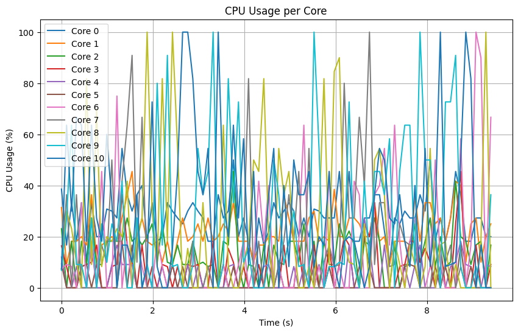

```
    Core  Average Usage  Max Usage
0      0      27.706977       54.5
1      1      22.110465       45.5
2      2      14.155814       45.5
3      3       8.108140       45.5
4      4       4.667442       27.3
5      5       2.733721       20.0
6      6      15.543023      100.0
7      7      15.884884      100.0
8      8      24.202326      100.0
9      9      27.280233      100.0
10    10      31.543023      100.0
```

```python
from diffusion import run_experiment

num_iterations = 100
grid = profiler.profile(run_experiment, num_iterations)
profiler.plot()
profiler.summary()
```

```
Length of x: 1000
Total elements: 1000000
calculate_z_serial_purepython took 2.189697027206421 seconds
Profiling took 2.4161 seconds.
Execution took 2.3394 seconds.
```

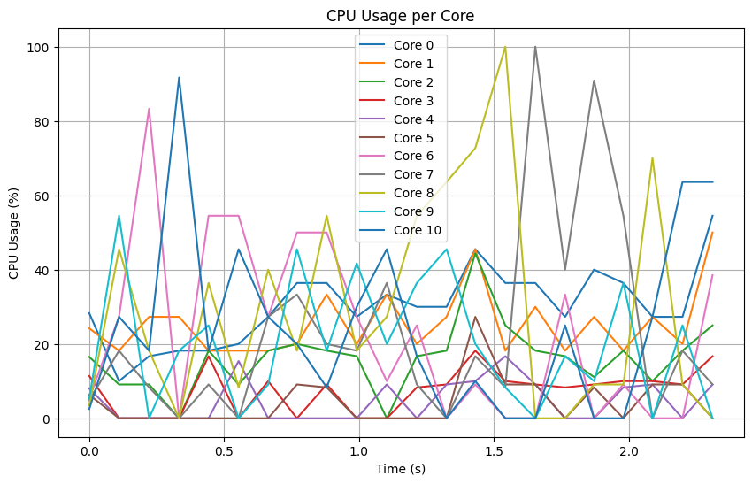

```
    Core  Average Usage  Max Usage
0      0      30.145455       54.5
1      1      25.463636       50.0
2      2      16.218182       44.4
3      3       7.504545       18.2
4      4       4.722727       16.7
5      5       4.350000       27.3
6      6      22.931818       83.3
7      7      23.745455      100.0
8      8      29.918182      100.0
9      9      19.809091       54.5
10    10      24.577273       91.7
```

```python
from JuliaSet import calc_pure_python

profiler2 = CPUProfiler()
desired_width = 1000
max_iterations = 300
grid = profiler2.profile(calc_pure_python, desired_width, max_iterations)
profiler2.plot()
profiler2.summary()
```